# Orthopédie

# 44 - Dépistage orthopédique

## LCH

La luxation congénitale de hanche concerne 3-20/1000 naissances, avec 1H4F. Il s’agit très rarement de luxation vraie, mais plus souvent de hanche instable pouvant se luxer progressivement pendant les premières semaines de vie. Presque tous les new-nés ont une instabilité de hanche susceptible d’évoluer en LCH. La découverte d’une LCH à âge > 3 mois ne peut être qu’un échec de dépistage. Dans ces cas, la pec nécessite en moyenne 20 jours d’hospitalisation. Les **fris** sont :

- ATCD fam de LCH
- présentation en siège
- limitation de l’abduction uni- ou bilatérale par hypertonie des adducteurs
- bassin asymétrique congénital
- anomalies posturales par contrainte anténatale importante (genu recurvatum, torticolis)

Le **dépistage** concerne tous les new-nés à la naissance, puis à chaque consultation jusqu’à l’âge de la marche. Il consiste à rechercher, enfant totalement déshabillé à plat sur le dos et relâché :

- limitation d’abduction : abduction < 60° par rapport au plan sagittal avec hanches à 90° (signe toujours présent)
- instabilité de hanche : manoeuvre de Barlow avec ressaut (pathognomonique d’instabilité de hanche)
  - pression axiale et rotation antihoraire du fémur sur plan axial, hanche à 90° (ressaut de luxation)
  - tractation axiale et rotation horaire du fémur sur plan axial, hanche à 90° (ressaut de réduction)

3 cas sont possibles pour la **manoeuvre de Barlow** :

- pas de ressaut : LCH irréductible
- pas de ressaut de luxation mais ressaut de réduction : LCH réductible
- ressaut de luxation et de réduction : hanche luxable

Si le dépistage trouve une LCH, on réalise une **imagerie** de la hanche :

- âge < 4 mois (avant apparition des noyaux épiphysaires) : échographie
- âge > 4 mois (après apparition des noyaux épiphysaires) : RX
- pec specialisée si anomalie radiologique

## Axes du MI

### Axe transversal

Physiologiquement, on retrouve :

- torsion interne fémorale
  - naissance : 35°
  - -1° par an jusqu’à maturité
  - 10-15° à maturité
- torsion tibiale externe
  - naissance : 0°
  - 30° à maturité

Des troubles de torsion peuvent donner une marche en rotation interne avec chutes à répétition (jeune enfant) ou en rotation externe (plus grand enfant). Normalement, à la marche, la patella doit être vue de face et le pied légèrement en dehors (8-10°). La mesure clinique des rotations se fait en décubitus dorsal jambes pendantes (genoux à 90° en bout de table). Une marche en rotation interne n’est pathologique qu’après 7 ans. Le traitement est réservé aux formes majeures (chirurgie).

### Axe frontal

Physiologiquement, les condyles (droit et gauche) et les malléoles (droit et gauche) se touchent. On parle de genu varum quand DIC > 0 (distance intercondylaire), de genu valgum si DIM > 0 (distance intermalléolaire).

- genu varum (distance intercondylaire > 0) : naissance jusqu’à 18-36 mois
- genu valgum (distance intermalléolaire > 0) : de 2 à 10 ans (max à 3 ans F, 4 ans H)
- morphotype frontal aligné à partir de la puberté (11 ans F, 13 ans H), les filles sont en léger genu valgum et les garçons en léger genu varum.

Des RX sont nécessaires si :

- en dehors des situations physiologiques
- déformations accentuées, asymétriques ou douloureuses

Le **genu varum** peut être lié à :

- rachitisme vitamino-résistant
- md Blount chez les enfants noirs (défaut de croissance de la partie proximale médiale des tibias)

Si une petite taille est associée, **genu varum ou valgum** doivent faire rechercher une md osseuse constitutionnelle (achondroplasie, dysplasie polyépiphysaire …)

## Rachis

Le dépistage est systématique chez l’adolescent. 80% des scolioses sont idiopathiques et indolores. 80% des scolioses idiopathiques concernent la fille.

### Scoliose

La scoliose est une déformation dans les 3 plans (frontal, sagittal, axial). Le dépistage repose sur la mee d’une **gibbosité** (pathognomonique), en vérifiant l’équilibre des **épaules** (mains jointes) et du bassin (visuellement). Il faut préciser le stade pubertaire (classification de Tanner) et la maturité osseuse (test de Risser). Avant d’affirmer la scoliose idiopathique, il faut exclure :

- attitude scoliotique (bassin déséquilibré, rotation vertébrale, disparition de la déviation sur cliché en décubitus)
- md Marfan : hyperlaxité tissulaire
- neurofibromatose : anomalies de la peau, taches café au lait
- malformation vertébrale : angiome, touffe pilleuse sur la ligne médiane
- anomalies de l’examen neurologique

La RX de dos et de profil permet de mesurer l’**angle de Cobb** (vertèbres les plus inclinées). La RX de profil n’est pas nécessaire pour la surveillance, donc peut ne pas être répété. La technique EOS permet de moins irradier, idéale pour le suivi. Une scoliose > 30° peut se compliquer de douleurs précoces à l’âge adulte, de tb respiratoires (diminution de CV et VEMS).

- si Cobb < 15° en croissance, il faut surveiller (clinique + RX) tous les 6 mois
- en cas d’évolutivité, voir un orthopédiste pédiatre
- la pec d’une scoliose évolutive repose sur le corset + kinésithérapie
- aucun sport n’est CI
- si formes sévères : chirurgie (artrhodèse vertébrale)

### Cyphose

La cyphose est une déformation dans le plan sagittal, souvent associée à une dystrophie rachidienne de croissance (md Scheuermann). C’est souvent une augmentation de la cyphose thoracique physiologique, révélée à l’adolescence par des douleurs. Il peut parfois s’agir d’une diminution ou d’une inversion de la lordose cervicale ou lombaire. Les conséquences sont principalement disgracieuses et douloureuses.

# 304 - Tumeurs osseuses

Les tumeurs osseuses sont souvent **bénignes**, **uniques** et **secondaires**.

## Diagnostic

Le diagnostic de tumeur maligne se fait sur la confrontation en RCP de clinique, imagerie et anapath.

### Clinique

- douleur osseuse
  - s’aggravant > 3 semaines
  - persistant au repos et la nuit
  - isolée, épargnant articulations et membres
- fracture sur traumatisme minime/discordant
- les sarcomes ne donnent pas d’AEG sauf sarcome d’Ewing
- signes neurologiques (tumeurs du rachis, localisation fréquente des métastases osseuses)
- masse palpable (rare, ssi très tardif ou os superficiels)
- tb croissance (déviation, inégalités de longueur)

### Imagerie

La RX (F+P suffisamment larges) est l’examen de 1e intention en cas de suspicion. L’analyse cherche :

- siège : diaphyse, métaphyse, épiphyse, étendue
- intra-osseux / extra-osseux (exostose) / les deux (malignité ?)
- ostéolytique / ostéocondensant / mixte (souvent)
- signes d’agressivité :
  - mal limitée
  - réaction périostée (triangle de Codman)
  - disparition de corticale
  - envahissement des parties molles (parfois en “feu d’herbe”)
- signes rassurants :
  - liseré de sclérose
  - bonne délimitation

## Tumeurs secondaires

0. Contexte
   - la plus fréquente des tumeurs osseuses malignes > 50 ans
   - fréquence : bassin > rachis > fémur (tout os possible)
   - âge > 50 ans
   - K ostéophile : sein, prostate, rein, poumon, thyroïde
1. Examens complémentaires
   - biologie : NFS, CRP (ostéite ?), EPP, PSA, bilan phosphocalcique (prévention complications d’hypercalcémie)
   - imagerie : RX poumons, TDM TAP, écho thyroïdienne, mammographie, scinti osseuse

## Tumeurs primitives

0. Tumeurs osseuses primitives
   - moins courantes (7/M/an)
   - âge > 40 ans
   - pas d’ATCD K personnel
1. Fris
   - mut RB1 : rétinoblastome familial et sarcome
   - mut TP53 (prédisposition aux sarcomes : sd Li-Fraumeni)
   - md exostoses multiples (= Bessel-Hagen) : mut EXT1/2 autodom
   - enchondromatose multiple (= Ollier)
   - ATCD irradiation
2. Examens complémentaires
   - si aspect bénin : pec chirurgie orthopédique
     - ostéome ostéoïde, kyste essentiel, exostose solitaire, fibrome non ossifiant
   - si aspect agressif, indéterminé ou doute : pec spécialisée
     - biologie de débrouillage : phosphocalcique (hypercalcémie souvent symptomatique en raison de sa rapidité d’installation), NFS, CRP
     - imagerie : TDM, IRM, scintigraphie dans des délais courts
   - biopsie (chirurgicale ou scannoguidée) en milieu spécialisé
3. Bilan d’extension (si malin)
   - IRM de l’os atteint (skip ?)
   - scinti osseuse
   - si ostéosarcome ou chondrosarcome : TDM thorax
   - si sarcome d’Ewing : TDM TAP + bilan médullaire (BOM et ponction)
   - ostéosarcome, chondrosarcome (15% M+ au dgn)
     - IRM de l’os atteint (skip ?)
     - TDM thorax (pas de méta abdo-pelv)
     - scinti osseuse
   - sarcome d’Ewing (25% M+ au dgn)
     - IRM de l’os atteint (skip ?)
     - TDM TAP
     - scinti osseuse
     - bilan médullaire (BOM et ponction)

[output not shown]

# 329 - SAU brûlures

## Généralités

Epidémiologie :

- 70% domestiques, 20% travail
- 30% < 15 ans, 15% < 2 ans
- FR : 150 000 cas/an dont 7 500 hospitalisations, 3 000 en centre de brûlés
- svt superficielles et peu étendues

4 mécanismes :

- thermique
- chimique (base plus grave que acide)
- électrique (haute tension plus grave, basse tension fris CV)
- radiations ionisantes

3 phases :

- J0-J3 (hypovolémique)
  - inflammation, hyperperméabilité capillaire
  - perte plasmatique par extravasation : exsudats (pertes définitives) et oedèmes (pertes temporaires)
  - risque : choc hypovolémique
- J3-J8 (résorption des oedèmes)
  - arrêt de l’inflammation
  - résorption oedèmes, hémodilution, polyurie réactionnelle
  - risque : surcharge vasculaire
- J8-cicatrisation (maladie des brûlés)
  - tb régulation thermique, hypercatabolisme azoté, déficit immunitaire
  - risque : dénutrition, infection (grave ssi surinfection)

## CAT

### Evaluation de gravité

Calcul de **surface** avec règle des 9 de Wallace (bien qu’imprécise et inadaptée pour enfants) :

- 9% tête (20% à 0-1 an, 15% à 5 ans, 10% à 15 ans)
- 9% chaque MS (paume main = 1%)
- 18% chaque MI (7% à 0-1 an, 12% à 5 ans, 17% à 15 ans)
- 36% tronc
- 1% OGE

Classification en **4 degrés** :

[output not shown]

La gravité selon le **nombre d’UBS** (Unit Burn Standard = % total brûlé + 3x(% surface degré 3))

- < 25 : mineure
- 25-50 : brûlure légère
- 50-100 : brûlure moyenne
- 100-150 : brûlure grave
- 150-200 : brûlure gravissime
- > 200 : brûlure mortelle

Le pronostic selon l’**indice de Baux** : AGE + (% surface degré 2-3) + 15*(nb de tares)

- < 50 : 100% survie
- 50-75 : 90% survie (réanimation)
- 75-100 : 35% survie (grand brûlé)
- 100-125 : 20% survie

Selon les **localisations** :

- face : risque vital, oedème svt important, gênant parfois perméabilité VAS. Oedème laryngé suspecté par voix rauque ou stridor. Une lésion thermique en dessous du larynx est rare car les gaz humidifiés transportent mal la chaleur. Suspecter lésions pulmonaires par inhalation de fumées. Les lésions sont svt causées par des gaz irritants, produits chimiques ou particules. Les lésions pulmonaires sont généralement associées à (confirmer par fibroscopie bronchique URG) :
  - brûlures profondes de la face,
  - voix rauque ou stridor
  - toux ou ronchi
  - expectoration de suies
- périnée : risque infectieux, parfois séquelles fonctionnelles majeures
- brûlures circulaires des membres : si profondes, peuvent se rétracter et former un garrot (ischémie distale)
- brûlures mains et pieds : peau dorsale fine, pec spécialisée

### PEC

#### Sur le terrain

- enlever vêtements
- refroidir brûlure à l’eau ambiante (15 min) puis froide (5 min)
  - pour diminuer la douleur et l’extension en profondeur
  - ssi 1e heure
  - éviter si état de choc ou hypothermie
  - lavage abondant (30 min) si brûlure chimique
- protéger, réchauffer le brûlé (drap propre ou stérile, gel hydrophile, couverture de survie)
- vérifier fonctions vitales :
  - respiratoire : liberté des voies aériennes, oxygénothérapie
  - hémodynamique : voie veineuse si brûlure grave à hospitaliser
  - neurologique : recherche d’autres lésions si tb conscience

#### Aux urgences

- 20-30 mL/kg pour la 1e heure de Ringer Lactate
- RX et ECG systématiquement
- intubation naso-trachéale si :
  - détresse respiratoire
  - suspicion inhalation fumées avec oedème de glotte après fibroscopie
- biologie : NFS, groupe, glycémie, urée,
- surveillance masse (suit hydratation et dénutrition)

#### Orientation

- hospitalisation simple si (ou)
  - surface = 15-25% (5% si nourrisson, 10% si vieillard)
  - lésions associées
  - > 3% de degré 3
  - alimentation impossible
- hospitalisation en centre de brûlés
  - surface = 25-40%
  - UBS = 50-100
  - non cicatrisé à J15
  - nécessité de chirurgie spécialisée
- hospitalisation en réa de centre de brûlés
  - surface > 40%
  - UBS > 100
  - terrain taré

## PEC selon situations

### Brûlure grave

- correction hydro-électrolytique : urg si surface > 10%
  - G5% : 2L/jour
  - 50% macromolécules (Ringer Lactate) + 50% colloïdes (albumine 4%) : 2 mL * surface * masse
- prévention antitétanique systématique (VAT-VAS)
- nutrition précoce, voie entérale de préférence
- surélévation zones brûlées si possible
- surveillance température

### Maladie des brûlés

- degré 1 ou 2 superficiel : cicatrisation dirigée
- degré 2 profond ou 3 : détersion macérative ou excision précoce puis autogreffe

La cicatrisation doit être obtenue en 3 semaines maximum, si possible. Sinon, les cicatrices sont toujours de qualité médiocre. Un bourgeon non épidermisé après 3 semaines devient scléreux et forme un sous-sol impropre à la greffe (davantage de rétractions, de brides …).

### Selon les causes

- brûlure chimique
  - lavage à l’eau abondant (30 min)
  - acide ou base : diphotérine (agent neutralisant)
  - brûlure au phosphore : éviter contact oxygène
  - brûlure à l’acide fluorhydrique : risque hypercalcémie mortelle
  - examen ophtalmologique
- brûlure électrique
  - lésions surtout profondes, peu visibles
  - mauvais pronostic : atteinte vasculaire, neurologique et infectieuse
  - surveiller rhabdomyolyse : fasciotomie (aponévrotomie) au moindre doute
  - amputation permet d’arrêter l’InRé sur rhabdomyolyse

# 344 - Infections des parties molles

## Généralités

### Abcès

0. Abcès
1. Contexte
   - souvent bien circonscrit
   - svt S. Aureus (doré)
   - évolution en 4 phases :
     - début (J1-J3) : début des signes locaux
     - collection (J3-J5) : maximum des signes locaux, début des signes généraux
     - fistulisation (J5-J8) : ulcération au sommet, évacuation du pus puis améliration clinique générale
     - cicatrisation : ulcération se ferme, cicatrice indélébile
2. Diagnostic (4 et)
   - augmentation de volume, souvent indurée
   - rougeur : pouls capillaire accéléré, érythème plus ou moins localisé,
   - douleur : spontanée et provoquée par palpation ou mouvement, lancinante, pulsatile, plus importante le soir (svt insomniante)
   - chaleur : le toucher avec le dos de la main perçoit l’hyper vascularisation localisée.
3. Traitement
   - drainage chirurgical indispensable :
     - tuméfaction incisée largement, les cloisons éventuelles sont effondrées, le tissu nécrosé ou infecté est enlevé (limite la récidive)
     - prélèvements bactériologiques systématiques
     - fermeture absente ou lâche
     - parfois drainage ou méchage
   - soins locaux poursuivis quotidiennement
   - patient revu en consultation à 48h (efficacité du traitement), suivi jusqu’à cicatrisation
   - ATB selon contexte
   - prévention antitétanique

### Infection systémique

Le **sepsis** est l’association de :

- T°>38°C ou T°<36°C
- FC > 90 bpm
- FR > 20/min
- leucocytes < 4 000/mm3 ou > 12 000/mm3

Il y a **sepsis sévère** (compliqué) si : (ou)

- dysfonction d’organe : hypoxémie, oligoanurie (débit urinaire < 0,5 ml/kg/h), tb coagulation, acidose métabolique
- hypoperfusion : acidose lactique, oligurie, encéphalopathie aiguë
- hypotension (PAS < 90 mmHg ou < 30% de la PAS habituelle chez HTA connu).

Il y a **choc septique** si l’hypotension est persistante malgré un remplissage vasculaire adapté. Les signes cliniques habituels sont :

- signes d’infection grave
- marbrures, froideur et cyanose des extrémités
- polypnée
- sueurs
- oligoanurie
- tb comportement

## Infections cutanées

### Folliculite

Il s’agit d’une pustule périfolliculaire centrée par un poil, pouvant être superficielle. Des soins locaux suffisent. La forme profonde est plus inflammatoire et évolue vers l’abcédation (furoncle) : orgelet du cil, sycosis de la barbe.

### Furoncle

Le furoncle est une infection d’un follicule pilo-sébacé favorisée par l’irritation cutanée, une hygiène insuffisante, l’acné, le diabète. Le traitement repose sur :

- ttt local
- ATB anti-staphylococcique (pristinamycine ou péni-M) si :
  - atteinte face ou terrain taré : ATB 10j
  - furonculose (récidive, chronique) : ATB 3 semaines

Les furoncles du **sillon nasogénien** ou de la **lèvre supérieure** doivent être particulièrement surveillés. L’infection peut diffuser vers le sinus caverneux grâce à l’anastomose veine angulaire-veine ophtalmique. Le risque est la thrombophlébite du sinus caverneux : staphylococcie maligne de la face nécessitant une hospitalisation en urgence, ATB parentérale (péni M et gentamycine).

### Anthrax

Il s’agit de la confluence de plusieurs furoncles, souvent dans le dos. Parfois, il s’agit d’une infiltration large, extensive, indurée. Le revêtement cutané laisse souvent place à des phlyctènes. Les signes généraux peuvent être importants, les traînées de lymphangites sont fréquentes. On traite par :

- soins locaux, voire drainage chirurgical
- ATB générale 10j (pristinamycine ou péni-M)

### Hydrosadénite (= abcès tubéreux)

Il s’agit de l’infection des glandes sudoripares, souvent aisselle, marge anale, mamelon. D’abord sous forme d’une nodosité arrondie peu douloureuse, elle évolue en collection sous-cutanée superficielle et s’ulcère rapidement. La région atteinte peut présenter plusieurs collections à des stades évolutifs différents. Le diagnostic différentiel est l’adénopathie. Le traitement associe :

- antiseptiques locaux
- drainage chirurgical des abcès voire exérèse profonde et complète des glandes infectées
- ATB générale 10j (pristinamycine ou péni-M)

## Infections sous-cutanées

Le terme anglo-saxon “cellulite” est impropre car il fait référence à un tissu cellulaire sous-cutané inexistant. Il doit être remplacé selon le type par :

- dermohypodermite bactérienne (= DHB = érysipèle), ttt med
- dermohypodermite bactérienne nécrosante (= DHBN), ttt chir urg
- fasciite nécrosante (=FN), ttt chir urg
- gangrène gazeuse, ttt chir urg

Ces 3 dernières infections doivent bénéficier d’un traitement chirurgical en urgence.

### DHB (= érysipèle)

C’est une infection aigüe non nécrosante mais extensive du derme et de l’hypoderme surtout aux MI et visage. Le traitement est uniquement médical :

- soins locaux (porte d’entrée)
- ATB 10-20j : péni-G IV puis relais oral par amoxicilline 10-20j,
- ! CI AINS
- prévention antithrombotique si fris

### DHBN-FN

Elles atteignent le derme et l’hypoderme. La fasciite nécrosante atteint le fascia superficiel voire le muscle. Elles évoluent vers la nécrose immuno-allergique des tissus hypodermiques puis épidermiques. Après incubation (1-4j si cervical ou membres, 5-14j si périnée), les signes généraux sont marqués et rapidement évolutifs vers le choc septique. Elle survient le plus souvent chez :

- > 50 ans
- diabétiques (25% des cas)
- hémopathies, K, md CV, pulmonaires, imD, enfants avec varicelle, alcool, toxicomanie

Une effraction cutanée est trouvée dans un cas sur deux. Le diagnostic ne devra cependant pas être éliminé devant un patient jeune sans ATCD.

Elles peuvent toucher :

- face et cou (“cellulite faciale ou cervicale”) : porte d’entrée souvent dentaire (“cellulite dentaire”), aggravée par les AINS en automédication
- membres (surtout MI)
- abdomen, périnée (gangrène de Fournier) : les germes responsables sont mixtes (BGN)

Ces infections nécrosantes se présentent de façon identique, la profondeur de l’atteinte n’est connue qu’en per-opératoire. Cependant la fasciite, plus grave car plus profonde, a tendance à évoluer plus vite, plus péjorativement et laisse davantage de séquelles. Il n’y a pas d’abcédation sauf dans certaines formes périnéales.

Le germe responsable est S. pyogenes (streptocoque bêta-hémolytique de groupe A) mais 40-90 % des DHBN-FN sont plurimicrobiennes (staphylocoque, anaérobies).

Le **traitement** repose sur :

- ttt symptomatique :
  - correction de l’hypovolémie
  - anticoagulants
  - aminés vasopressives, ventilation mécanique
  - correction hydroélectrolytique
- ATB IV : uréidopénicilline (pipéracilline + tazobactam) + gentamycine
- chirurgie : débridement large, excision des tissus nécrosés
  - prélèvements bactériologiques multiples
  - drainage possible
  - ttt médiastinite si cervicale
  - dérivation digestive si périnée
- oxygénothérapie hyperbare à discuter

Mortalité : 30% pour les formes cervicales et des membres Mortalité : > 50 % dans les formes périnéales Séquelles fonctionnelles et esthétiques majeures

### Gangrène gazeuse

Il s agit d’une infection nécrosante avec production de gaz par des germes anaérobies d ’origine tellurique. La **létalité** est de 25 %. L’incubation est très rapide (heures), l’infection évolue très rapidement. Le germe le plus fréquent est le Clostridium perfringens (ou septicum ou oedematiens). Les signes généraux prédominent le tableau : **choc septique sans hyperthermie**. Les signes locaux sont marqués par :

- douleur en striction du membre
- oedème pâle prenant le godet
- odeur putride
- crépitation sous-cutanée (emphysème, visible sur RX)
- pas d’adénopathie

La **pec** comprend :

- ttt du choc septique
- ATB : péni G + métronidazole
- chir urg : excision des tissus nécrotiques, voire amputation en zone saine
- oxygénothérapie hyperbare après chirurgie

## Infections de la main

### Panaris

0. Panaris
1. Contexte
   - infection primitive aigüe des parties molles d’un doigt
   - très fréquent
   - souvent S. aureus (doré) ± autres germes (streptocoques, entérocoques, anaérobies)
   - inoculation souvent méconnue (plaie négligée, traumatisme unguéal, piqûre septique)
   - évolution en 3 phases
     - inoculation : douleur aigüe puis intervale libre
     - inflammation localisée (= phase phlegmasique)
- phase de collection + collection : : douleur lancinante, insomniante, signes locaux nets (tuméfaction phlycténulaire, tendue, rouge, chaude), signes régionaux souvent discrets (hyperthermie isolée, traînée de lymphangite, adénopathies)
2. Formes cliniques
   - phlycténoïde péri-unguéal : le plus fréquent, rechercher systématiquement collection sous-unguéale (panaris sous-unguéal) ou pulpaire (panaris en bouton de chemise)
   - anthracoïde : superficiel, furoncle de la face dorsale du doigt
   - sous-cutané : pulpaire, très douloureux, tendance à diffuser aux espaces plus profonds (gaine digitale, os, articulation, face dorsale du doigt) (panaris en bouton de chemise)
   - proximal palmaire : risque de diffusion vers l’espace commissural et les gaines digitales (phlegmon)
   - dorsaux : risque de diffusion aux articulations interphalangiennes et métacarpophalangiennes
3. Complications
   - diffusion aux gaines digitales (phlegmon de la gaine des fléchisseurs)
   - diffusion aux espaces celluleux palmaires ou dorsaux (phlegmon (= cellulite) palmaire ou dorsal)
   - diffusion aux articulations et aux os (arthrite, ostéite)
4. Examens complémentaires
   - aucun si forme typique
   - si cas douteux (faux panaris d’Osler de l’endocardite) : NFS, CRP, VS à la 1e heure
   - glycémie à jeun (diabète = fris récidive)
   - RX selon clinique : corps étranger, arthrite,ostéite, panaris refroidi (évolution longue)
5. Traitement
   - phase inflammatoire :
     - bain antiseptique (chlorhexidine, providone iodée) : 3/jour
     - contrôle à 48h : si pas d’amélioration, chirurgie
   - phase de collection :
     - chirurgie :
       - excision des tissus infectés, sans fermeture
       - si panaris sous-unguéal : résection tablette unguéale (partielle ou totale)
       - mise à plat, recherche de fusée septique
       - prélèvements bactériologiques
     - pansement gras après antisepsie tous les 2j après chirurgie
     - contrôle à 24h, cicatrisation dirigée pendant 2-3 semaines
   - prévention antitétanique systématique
   - pas d’ATB, pas de rééducation

### Phlegmon des gaines des fléchisseurs

C’est une urgence chirurgicale. Il y a 3 types de gaines des fléchisseurs :

- 1 gaine du long fléchisseur du pouce (digitocarpienne radiale)
- 1 gaine commune des fléchisseurs (digitocarpienne ulnaire), enveloppant l’ensemble des fléchisseurs des doigts longs (II à V) dans le canal carpien
- 3 gaines digitales pour les IIe, IIIe et IVe doigts

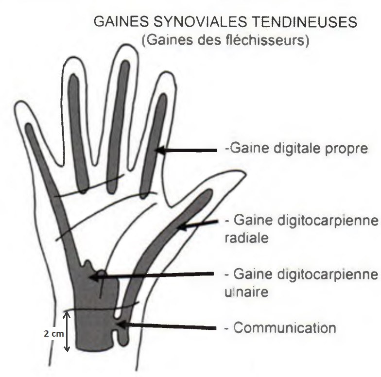

0. Phlegmon des gaines des fléchisseurs
1. Contexte
   - souvent S. aureus (doré) devant S. pyogenes (bêta-hémolytique A), association microbienne fréquente
   - évolution : plus rapide si inoculation directe (plaie, morsure, piqûre) que phlegmon à bascule (infection)
     - stade I (inflammatoire) : gaine synoviale distendue, inflammatoire, liquide claire ou louche
     - stade II (purulent) : synoviale turgescente, hypertrophique, liquide purulent
       - IIa : hypertrophie localisée
       - IIb : hypertrophie sur toute la longueur
     - stade III (nécrotique) : nécrose tendineuse
2. Complications
   - diffusion en surface (fistulisation cutanée)
   - diffusion en profondeur (phlegmon des espaces celluleux, arthrite, ostéite, myosite antébrachiale)
   - septicémie rare
3. Diagnostic
   - douleur à la porte d’entrée, puis le long de la gaine (max au cul de sac proximal), pulsatile et insomniante
   - doigt tuméfié
   - extension passive ou contre résistance aggrave la douleur
   - fièvre et adénopathies
   - crochet irréductible signe une évolution inquiétante. La résolution spontanée du crochet évoque la rupture tendineuse
   - phlegmon à bascule atteint pouce, auriculaire et tendons du canal carpien par communication entre gaine radiale et ulnaire
4. Examens complémentaires
   - RX (corps étranger, complications ostéo-articulaires)
5. Traitement
   - chirurgie (urg)
     - excision porte d’entrée (= parage)
     - exploration des culs de sac proximal et distal
     - multiples prélèvements bactériologiques
     - lavage abondant de la gaine (sérum physiologique)
     - si stade IIb : excision synoviale hypertrophique (incision brisée le long de la gaine)
     - si stade III : excision synoviale hypertrophique et tendon nécrosé (incision brisée le long de la gaine)
   - porte d’entrée en cicatrisation dirigée, les autres incisions sont fermées lâchement sans drainage
   - ATB IV 48h puis PO 15j selon ATBg (bêta-lactamines + aminosides)
   - prévention antitétanique systématique, rage et pasteurellose si morsure
   - soins locaux 2-3 semaines
6. Complications
   - adhérences tendineuses responsables de raideur (fréquent)
   - nécrose des fléchisseurs : reconstruction difficile (amputation digitale fréquente)
   - complications trophiques variables

### Phlegmon des espaces celluleux

C’est une DHB souvent non nécrosante, nommée de façon impropre “cellulite”. Il y a 2 espaces celluleux de la main :

- espace dorsal, fin
- espace palmaire : superficiel et profond
0. Phlegmon des espaces celluleux
1. Contexte
   - souvent S. aureus (doré), associé parfois à d’autres germes (streptocoques, entérocoques voire anaérobies)
   - souvent contamination par inoculation directe, parfois par panaris ou phlegmon de gaine
2. Diagnostic
   - oedème est diffus, important au dos de la main
   - douleur maximale au site de développement de l’infection
   - si phlegmon palmaire profond, douleur à la mobilisation passive des doigts
   - phlegmon commissural diffuse souvent vers les doigts
3. Traitement
   - chirurgie (urg) :
     - excision porte d’entrée
     - prélèvements bactériologiques multiples
     - excision des tissus nécrosés, sauvegarde des tendons
     - lavage (sérum physiologique)
     - porte d’entrée en cicatrisation dirigée, les autres incisions fermées lâchement (possible drainage)
   - immobilisation en position de fonction (intrinsèque +), mais doigts mobilisés précocement
   - ATB, prévention antitétanique et surveillance comme phlegmon des gaines

## Situations particulières

### Morsures

La RX est systématique (corps étranger ?). Le traitement est :

- chirurgie
- prévention tétanos et rage
- sérologie VIH et hépatite si morsure humaine
- ATB systématique (VS staph, strep, anaérobies et pasteurellose)

Germes à vérifier :

- rat : leptospirose
- porc ou poisson : rouget du porc
- lièvre : tularémie

### Injection sous haute pression

C’est une indication à la chirurgie en urgence. Les symptômes sont très trompeurs car non alarmants. Les lésions sont dues à :

- distension physique
- toxicité chimique du produit injecté
- diffusion du produit dans les espaces, créant des ischémies digitales

L’évolution se fait pendant quelques jours après l’accident. Les complications sont fréquentes (infections secondaires, raideurs, amputations digitales).

# 357 - Lésions péri-articulaires

## Epaule

### Péri-claviculaires

#### Disjonction acromio-claviculaire

0. Disjonction acromio-claviculaire
   - svt sujet jeune par chute sur le moignon de l’épaule
1. Diagnostic clinique
   - attitude du traumatisé du MS
   - abduction active < 90° (limitée par douleur)
   - décrit en 4 stades (Rockwood)
   - selon stade : touche de piano, déformation, tiroir antéro-postérieur
2. Complications si stade IV
   - perforation cutanée
   - irréductibilité
   - lésion osseuse, vasculo-nerveuse, pulmonaire
3. Examens complémentaires
   - RX (fracture ? complication pulmonaire ? déplacement ?)
     - face du cintre acromio-claviculaire
     - profil de la scapula
     - si doute diagnostique : face avec traction inférieure (5 kg) bilatéral comparatif
   - si traumatisme complexe ceinture scapulaire : TDM épaule
4. Traitement
   - stade I, II : fonctionnel (Dujarier 5-10j, activités à J15)
   - stade I hyperalgique, II, III : orthopédique (Dujarier 3 semaines)
   - stade III jeune sportif, IV : chirurgie
   - si séquelle douloureuse ou instabilité secondaire : ligamentoplastie, transfert ostéotendineux ou résection quart externe clavicule

| Stade Rockwood | Ligament | Touche de piano | Déformation Tiroir antéro-postérieur |
| --- | --- | --- | --- |
| I | entorse acromio-claviculaires | non | non |
| II | rupture acromio-claviculaires | modérée | non |
| III | rupture II + coraco-claviculaires | OUI | modérée |
| IV | rupture III + chape trapézo-deltoïdienne | OUI | OUI |

#### Disjonction sterno-claviculaire

0. Disjonction sterno-claviculaires
   - rares mais risque de complications vasculaires graves
   - AVP dans 50%
   - mécanisme : compression cage thoracique, directe (antéro-postérieure) ou indirecte (latérale)
1. Diagnostic
   - TDM IV (complication vasculaire ?)
   - décrit en 3 stades
2. Examens complémentaires
   - RX (thorax face, sternum profil) systématiques mais interprétation délicate
3. Traitement
   - stade I, II : fonctionnel (Dujarier 5-10j antalgique)
   - stade II, III : orthopédique (Dujarier 6 semaines)
   - chirurgie (III instables après réduction) : ligamentoplastie et brochage
   - si séquelle douloureuse ou esthétique : résection quart interne de clavicule

| Stade | Lésion | Clinique | Déformation |
| --- | --- | --- | --- |
| I | entorse sterno-claviculaires | douleur élective sterno-claviculaire | non |
| II | subluxation (rupture sterno-claviculaires) | mobilité anormale antéro-postérieure | modérée |
| III | luxation antérieure (rupture costo-claviculaires) | – tuméfaction volumineuse – épaule raccourcie, projetée en avant – tête inclinée vers la lésion – gêne augmentée par le décubitus | OUI |
|  | luxation postérieure (rupture costo-claviculaires) | – dépression comblée par l’oedème – compression vasculaire, nerveuse ou viscérale (dysphagie, gêne respiratoire) – réduction en urgence |  |

### Scapulo-humérales

#### Luxation antérieure

Des lésions peuvent être associées :

- fractures
  - fracture ou écoulement de cavité glénoïdale (cisaillement), fris récidive
  - encoche humérale (= Malgaigne = Hill-Sachs), 30% des premières luxations, impaction de la face postéro-supérieure de la tête sur le rebord glénoïdien antéro-inférieur, fris récidive
  - tubercule majeur (20%), dans le prolongement de l’encoche humérale, fixation chirurgicale nécessaire, facteur protecteur de récidive
  - col chirurgical ou fracture complexe de l’extrémité supérieure humérale
- désinsertion du labrum et de la capsule en antéro-inférieur (= lésion de Bankart), peut être associée à lésions scapulo-humérales inférieures
- rupture de la coiffe des rotateurs
  - 50% si luxation à 50 ans, précède la luxation si sujet âgé
  - si sujet jeune, la luxation rompt les tendons dégénératifs
  - souvent rupture du supra-épineux (rupture du subscapulaire rare)
  - lésions transfixiantes si > 60 ans, face profonde si jeune
  - impotence fonctionnelle, douleurs > 3 semaines
  - arthroscanner confirme le dgn et évalue les possibilités chirurgicales
- neurologiques (30% de l’ensemble des luxations)
  - 50% nerf axillaire (plus rare : suprascapulaire, musculo-cutané)
  - plexus brachial peut être étiré. Si basse énergie, récupération totale spontanée. Si haute énergie, rééducation et chirurgie indispensables, récupération fonctionnelle partielle
- capsulite rétractile (rare, surtout 40-60 ans)
  - physiopathologie proche de l’algoneurodystrtophie
  - diagnostic par diminution mobilité passive
  - prévention : immobilisation courte si > 40 ans
- récidive habituelle si jeune jusqu’à instabilité antérieure chronique
  - signe spécifique : test d’appréhension (bras à 90°, faire rotation latérale forcée et pousser épaule vers l’avant). Positif si le patient demande d’arrêter. Le ttt est chirurgical (arthroscopie ou butée coracoïdienne de Latarjet).

#### Luxation postérieure

0. Luxation scapulo-humérale postérieure
1. Contexte
   - rares (2%), souvent méconnues (2/3)
   - par crise comitiale généralisée, delirium tremens ou électrocution
   - souvent bilatérale
   - suspectée par perte de RE
2. Diagnostic
   - RX (face et profil scapulaire de Lamy ou axillaire)
     - superposition tête humérale sur cavité glénoïdale
     - svt encoche antéro-médiale de la tête (= Mac Laughlin)
3. Traitement
   - si > 3 semaines : invétérée, réduction chirurgicale si décidée

#### Luxation inférieure

Très rare, elle est nommée “erecta” car le membre supérieur est en abduction complète et forcée. La réduction urgente est souvent faite sous anesthésie.

### Coiffe des rotateurs

- douleur en avant du moignon de l’épaule, irradiant vers le coude, nocturne
- l’association mobilité passive complète et active limitée oriente vers une pathologie de la coiffe

#### Test des mobilités

Test passif et actif, patient assis, de :

- flexion (élévation antérieure)
- abduction (élévation latérale)
- élévation antéro-latérale
- RE1 (coude au corps), RE2 (abduction 90°, avant-bras vers le haut), RE3 (flexion 180°, avant-bras vers l’arrière)
- RI (niveau atteint par le pouce)

#### Test des muscles

- recherche d’amyotrophie des fosses supra- et infra-épineuses, deltoïde, décollement scapula (déficit dentelé antérieur)
- recherche de souffrance de la coiffe
  - conflit antéro-supérieur : test de Neer (bras en RI, douleur à l’élévation antéro-latérale du bras)
  - conflit antéro-supérieur ou antéro-médial : test de Hawkins (bras en RE, douleur à l’abaissement passif de l’avant-bras)
  - conflit antéro-médial : test de Yocum (bras sur l’épaule opposée, douleur à l’élévation du coude), signe le plus reproductible

| Muscle | Test | Diagnostic |
| --- | --- | --- |
| supra-épineux (abduction) | signe de Jobe (élévation antérolatérale, pouces vers sol, examinateur presse vers le bas) | – douleur seule = tendinite – douleur + impotence = rupture |
| infra-épineux et petit rond (RE) | signe de Patte (élévation antérolatérale, avant-bras verticaux, examinateur presse vers l’avant) | – douleur = tendinite long biceps – impotence = amyotrophie RE – chute du bras = rupture infra-épineux |
|  | signe du portillon (RE1 passif) | – bras revient vers le ventre = rupture RE |
| subscapulaire (RI) | lift-off test (= Gerber) (main derrière le dos) | – main indécollable du dos = rupture |
|  | belly-press test (ssi lift-off test impossible) (main sur le ventre, examinateur tente de décoller la main) | – impotence = atteinte |
| tendon du long biceps | palpation passive et en flexion (au sillon intertuberculaire) | – douleur = tendinite |
|  | palm-up test (= Gilcreest) (flexion 90°, paumes vers le haut, examinateur presse vers le bas) | – douleur = tendinite – ressaut douloureux = instabilité |
|  | signe de Popeye (flexion du coude) | – tuméfaction = rupture spontanée tendon |

#### Examens complémentaires

En première intention : RX face sans rotation, en RI et en RE, profil de scapula

En 2e intention :

- échographie (insuffisant pour indication opératoire)

Bilan pré-opératoire par IRM, arthroscanner ou arthro-IRM

#### Traitement

- tendinopathie non rompue :
  - ttt médical (antalgiques, AINS voire infiltration) et rééducation
  - acromioplastie ssi dernier recours chez l’adulte
- rupture de coiffe
  - ttt médical
  - ttt chirurgical ssi pas d’amélioration en 6 mois

### Diagnostics différentiels

#### Fracture clavicule

0. Fracture de la clavicule
1. Contexte
   - souvent tiers moyen
   - dépister complications cutanées, pluro-pulmonaires, vasculaires, neurologiques
2. Diagnostic RX
3. Traitement
   - orthopédique (écharpe ou Dujarier) 4-6 semaines
   - chirurgie ssi quart latéral, compliquée, pseudarthrose ou impaction du moignon de l’épaule
4. Evolution svt favorable malgré cal vicieux inesthétique

#### FESH

0. FESH
1. Contexte
   - fréquent chez le sujet âgé ostéopénique
   - souvent fracture engrenée
2. Traitement
   - orthopédique (Dujarrier) 6 semaines + rééducation passive à S3
   - chirurgie ssi déplacée : ostéosynthèse ou arthroplastie

#### Pathologies acromio-claviculaires

0. Pathologies dégénératives de l’articulation acromio-claviculaire
1. Contexte
   - instabilité post-traumatique
2. Clinique
   - conflit sous-acromial (test Neer, Hawkins, Yocum)
   - signes spécifiques :
     - douleur exquise palpation interligne acromio-claviculaire
     - cross-arm test (flexion 90°, coude fléchi, avant-bras horizontal, main rejoint l’épaule opposée)
3. Diagnostic RX (ou arthroscanner pour bilan de coiffe)
   - signes d’arthrose (pincement interligne, ostéophytes, ostéo-condensation, géodes d’hyperpression sous-chondrales). Les ostéophytes inférieurs peuvent donner un conflit sous-acromial.
4. Traitement (ou)
   - infiltration (corticoïdes retards)
   - chirurgie : résection acromio-claviculaire (arthroscopie si possible)

## Genou

### Ligaments

Une lésion est **bénigne** si le système central n’est pas touché. Le LCP et le plan médial peuvent cicatriser (contrairement à LCA et plan latéral). Le LCA s’attache en avant, en haut et latéralement.

| Lésion | triade antéro-interne (LCA + LCM + PAPI) | triade postéro-interne (LCP + LCM + PAPI) | triade antéro-externe LCA + LCL + PAPE | recurvatum (LCP + PAPI + PAPE) | LCM (entorse) | LCA |
| --- | --- | --- | --- | --- | --- | --- |
| Situation | n°1 association football, ski | rare | très rare | accident du tableau de bord | très fréquente | 20-25 ans (shoot dans vide) |
| Mécanisme | VALFE (varus, RE, semi-flexion) | extension + valgus | VARFI (varus, RI, semi-flexion) | recurvatum | valgus | hyper-extension |
| Poursuite | pentade interne (+ LCP) | pentade interne (+ LCA) | pentade externe (+ LCP) | pentade postérieure (+ LCA) |  |  |

#### Lésion ligamentaire genou

0. Lésion ligamentaire genou
   - bénigne si pivot central OK (sinon : grave)
   - LCP et plan médial cicatrisent (pas LCA ni plan latéral)
   - très souvent lésion méniscale associée (désinsertion ou lésion périphérique)
   - chez l’enfant : souvent vers 7 ans (sport), mécanisme lent (VS décollement épiphysaire)
     - rupture LCM
     - avulsion surface préspinale (insertion du LCA)
     - décollement épiphysaire tibial
1. Clinique
   - douleur : due à l’hémarthrose (indep de gravité des lésions)
   - craquement : signe de gravité
   - sensation de déboitement : lésion pivot central (LCA, LCP)
   - impotence fonctionnelle
   - gonflement : hémarthrose (contemporain, dû à rupture pivot central) ou hydarthrose (secondaire, dû à rupture méniscale ou ligamentaire périphérique)
   - blocage : relatif (hémarthrose, hydarthrose) ou élastique en flexion (lésion méniscale)
2. Examens
   - imagerie
     - RX face, profil, vues axiales des patellas (30°, 60° et 90°)
     - IRM à 10j du traumatisme
     - artériographie ou angioscanner ssi luxation ou suspicion pentade (lésion artère poplitée ?)
     - clichés dynamiques (AG) ssi luxation genou, suspicion pentade ou avant réparation ligamentaire complexe
       - face en extension : valgus et varus forcé
       - face en flexion 20° : valgus et varus forcé
       - profil en flexion 20° : translation antérieure et postérieure
       - profil en flexion 90° : tiroir antérieur et postérieur
       - profil en extension et en recurvatum
   - testing ligamentaire après radio, difficile si hémarthrose (le faire 10j après), évaluer appareil extenseur
3. Traitements
   - entorse LCM (très fréquent, douleurs longues à disparaitre : 3 mois)
     - genouillère 15 jours, antalgiques, AINS, glaçage
     - si douleurs importantes : attelle amovible quelques jours
     - rééducation précoce
   - rupture LCA (instabilité qui favorise lésions méniscales et arthrose)
     - svt ligamentoplastie
     - ttt fonctionnel ssi sédentaire sans instabilité
     - arrêt sport 6-9 mois, rééducation précoce
   - rupture LCP
     - si isolé
       - ttt fonctionnel
       - ttt orthopédique (lésion plus grave)
       - ttt chirurgical (avulsion ou < 35 ans)
     - si associée à d’autres lésions ligamentaires : chirurgie

#### Luxation fémoro-patellaire

0. Luxation patella (fémoro-patellaire)
   - en dehors, sur terrain prédisposant (dysplasie de trochlée)
1. Clinique
   - hémarthrose constante (rupture ligament fémoro-patellaire médial)
   - test de Smillie (tendance à luxation ?) : flexion genou en pressant le bord médial patellaire (appréhension ou subluxation)
2. Traitement orthopédique urg : attelle amovible extension 3 semaines (appui autorisé)

#### Luxation fémoro-tibiale

0. Luxation genou (fémoro-tibiale)
1. Examens complémentaires
   - urg artériographie ou angioscanner
2. Traitement
   - réduction sous AG, puis :
     - MI non ischémique : attelle + surveillance
     - MI ischémique, OK après réduction : attelle + artériographie (chirurgie vasculaire ?)
     - MI ischémique après réduction : fixateur externe + pontage veineux + fasciotomies de décharge
   - chirurgie urg si irréductible ou ouverte
   - chirurgie secondaire selon lésions associées

### Ménisques

Le ménisque médial est en C, le latéral est en O (CItrOEn). Le latéral est plus mobile car insertion capsulaire incomplète (hiatus poplité). Les ménisques peuvent cicatriser. La rupture peut être :

- longitudinale postérieure, la plus fréquente. Elle peut évoluer vers une languette ou un anse de seau qui peut se luxer dans l’échancrure.
- horizontale, pouvant créer un kyste méniscal (surtout ménisque latéral)
- radiaire
0. Lésions méniscales
   - 75% ménisque médial
   - souvent jeune adulte
   - souvent isolée, parfois secondaire à lésion ligamentaire
   - souvent rupture longitudinale (départ postérieur, évolue vers languette ou anse de seau, pouvant se luxer dans l’échancrure)
1. Clinique
   - douleur
   - douleur palpation interligne articulaire (cri de Oudart)
   - épanchement (hydarthrose répétitives après effort)
   - dérobement
   - blocages répétés en flexion (si blocage aigu élastique en flexion, luxation d’anse dans l’échancrure)
2. Examens
   - examen genou complet (choc patellaire, os, ligaments)
   - test d’Apley (= grinding test) : décubitus ventral, genou à 90°, exam grind
   - test de Mac Murray : décubitus dorsal, genou à 90°, exam RE
   - RX : F+P, axiales des patellas, en charge en extension, en Schuss
   - IRM permet diagnostic
3. Traitement (souvent arthroscopie ambulatoire)
   - sutures méniscales si lésion de portion vascularisée du ménisque (indications élargies chez l’enfant)
   - ménisectomies économiques (limite risque arthrose secondaire)
   - réduction de l’anse de seau urg si blocage élastique aigu en flexion du genou
4. Suites
   - appui autorisé immédiatement (sauf suture méniscale)
   - rééducation rarement nécessaire (sauf suture méniscale)
   - évolution rapidement favorable

Une lésion méniscale médiale sur genu varum doit faire réaliser :

- RX face des 2 MI en charge (pangonogramme)
- discuter réaxation (surtout si pincement articulaire médial)

## Cheville

### Ligaments

0. Lésions ligamentaires de la cheville
   - entorse de cheville : 6000 cas/jour en France
   - svt mécanisme en varus équin forcé (flexion plantaire + supination), sans chute
   - svt avec lésion rétinaculum des extenseurs
   - parfois avec fracture bimalléolaire
   - 90% des traumatismes en varus équin du jeune homme = entorse lig collatéral latéral (= talo-fibulaire antérieur)
1. Diagnostic clinique
   - douleur
   - hématome en oeuf de pigeon (rupture lig talo-fibulaire antérieur)
   - impotence fonctionnelle
2. Examens complémentaires
   - clinique
     - palpation des malléoles et base du 5e métatarsien (fracture ?)
     - palpation base 5e métatarsien (fracture-alvusion par traction du court fibulaire)
     - palpation rétinaculum
     - palpation tendon calcanéen, manoeuvre de Thompson (pression sur mollet doit faire flexion pied)
     - palpation faces latérale et médiale articulation sous-talienne (entorse)
     - palpation interlignes médio-tarsienne de Chopart (calcanéo-cuboïdienne et talo-naviculaire) tarso-métatarsienne de Lisfranc à la recherche d’une entorse du médio-pied.
   - RX F+P, face en rotation médiale si critères d’ottawa
   - à J5, l’échographie peut compléter l’examen clinique
3. Traitement : protocole RICE
   - traitement local : protocole RICE
     - Rest : décharge partielle ou totale selon douleurs (7 jours), cannes anglaises
     - Ice : glaçage 4 fois par jour
     - Compression : bandages élastiques ou attelles avec compartiments gonflables
     - Elevation
   - traitement orthopédique :
     - orthèse (après période de repos 7 jours) pendant 3-6 semaines
     - contention légère par chevillère élastique (si bénigne)
     - botte plâtrée/résine 4-6 semaines (si hyperalgie)
   - traitement médicamenteux :
     - paracétamol, AINS
     - HBPM dose isocoagulante ssi immobilisation stricte, décharge totale ou fris thrombose
   - rééducation 10-20 séances
   - chirurgie (suture ligaments) si entorse grave isolée chez adulte jeune sportif
4. Evolution
   - cs à J5
   - svt évolution favorable en 6 semaine

Chez l’**enfant**, les ligaments sont plus résistants que le cartilage de conjugaison. Le traumatisme en varus équin forcé donne une fracture Salter 1 (malléole latérale, svt non déplacée). Il n’y a pas de douleur ligamentaire ni d’hématome en oeuf de pigeon. La RX est systématique. Le traitement est orthopédique : botte plâtrée 3-6 semaines.

**Critères d’Ottawa** :

- patient < 18 ou > 55 ans
- patient 18-55 ans avec douleur et :
  - impossibilité d’appui dans l’heure post-traumatique (impossible de faire 4 pas)
  - sensibilité palpation malléole, naviculaire ou 5e métatarsien
- pas d’amélioration à J5

### Fractures

| Fracture fibula | inter-tuberculaire oblique ou spiroïde (65%) | sus-tuberculaire (25%) |  |  | sous-tuberculaire (5%) |  |
| --- | --- | --- | --- | --- | --- | --- |
|  |  | col fibulaire | 5-7 cm au-dessus des ligaments | juste au dessus des ligaments |  |  |
| Nom | Dupuytren basse | Maisonneuve | Dupuytren |  |  |  |
| Mécanisme | RE | abduction | abduction | abduction + RE | adduction |  |
| Ligament tibio-fibulaire antéro-inférieur | OK | rompus diastasis tibio-fibulaire |  |  | OK |  |
| Membrane interosseuse | OK | rompue |  | OK |  |  |

Il peut y avoir une rupture du lig médial à la place de la malléole médiale : c’est une fracture bimalléolaire d’intention.

# 358 - Ostéosynthèse et prothèses

## Consolidation osseuse

### Phases

1. **Inflammation** : hématome et inflammation par rupture des vx centro-médullaires, du périoste et des tissus voisins
   - monocytes et macrophages résorbant les débris et extrémités osseuses
   - cellules mésenchymateuses pluripotentes, angiogènes et ostéogènes, permettant la formation d’un tissu de granulation (protéique) entre les fragments osseux
2. **Prolifération** :
   - de J2 à S3, les cellules mésenchymateuses deviennent chondroblastes et fabriquent le cal mou (fibro-cartilagineux)
   - en parallèle, des ostéoblastes fabriquent un cal au niveau du périoste (ossification intramembranaire)
3. **Remodelage** :
   - à partir de S4, le cal mou s’ossifie. On peut voir le cal en RX à partir de J30
   - le remodelage du cal, guidé par les contraintes de compression et traction, dure 18-24 mois jusqu’à sa forme définitive

### Facteurs défavorables

- âge, tb métaboliques (diabète)
- tabac (néovascularisation diminuée)
- traumatisme à haute énergie (lésions majeures des tissus mous)
- trait de fracture oblique (pas de compression des fragments)
- fracture ouverte (fuite de l’hématome, risque infectieux)
- immobilisation non satisfaisante
- écart inter-fragmentaire important ou incarcération de tissu mou

### Consolidation pathologiques

- cal vicieux : consolidation dans une position non anatomique dû à un défaut de réduction initiale ou un déplacement secondaire. Il peut être corrigé par une ostéotomie de réaxation.
- retard de consolidation : pas de consolidation > 2x le délai normal de consolidation (souvent 3 mois)
- pseudarthrose : pas de consolidation > 6 mois
  - pseudarthrose septique
  - pseudarthrose atrophique : pas de cal osseux, dû à une absence de vascularisation (dépériostage agressif pendant la chirurgie ou écart inter-fragmentaire important)
  - pseudarthrose hypertrophique : élargissement des extrémités osseuses par appositions périostées (image RX en patte d’éléphant)

La pseudarthrose septique est pec par (et) :

- exérèse des tissus infectés
- changement de l’ostéosynthèse
- reconstruction osseuse (greffe)
- ATB probabiliste puis adaptés aux prélèvements per-opératoires

La pseudarthrose aseptique est pec par (et) :

- traitement de la cause et des facteurs défavorables à la consolidation osseuse
- traitement chirurgical : modification de l’ostéosynthèse et autogreffe osseuse

## Ostéosynthèse

La réduction puis l’ostéosynthèse permettent une contention et une mobilisation rapide du membre. La réduction peut être à **foyer ouvert** si l’abord chirurgical est possible, sinon à **foyer fermé** par des manoeuvres externes. Il existe 3 **types** d’ostéosynthèse :

- ostéosynthèse latéro-corticale par plaque : permet une réduction la plus anatomique possible mais nécessite un dépériostage. Le foyer de fracture est ouvert, entraînant la fuite de l’hématome périfracturaire.
- ostéosynthèse centromédullaire par clou : le foyer fracturaire n’est pas abordé, ce qui évite la fuite de l’hématome périfracturaire
- ostéosynthèse par fixateur externe : indiqué si fracture largement ouverte ou en traitement d’attente

### Surveillance

- RX post-op immédiat : réduction, position du matériel, déplacement secondaire
- signes généraux, constantes, aspect local, cicatrice, signes infectieux, TVP, sd loges
- cs de contrôle à J7, J21 … clinique et radiologique

### Complications

Le matériel d’ostéosynthèse doit être enlevé s’il crée une gène, s’infecte ou perturbe la fonction du membre. Il ne peut être enlevé que si la consolidation est complète (18 mois pour clou centromédullaire tibial).

- TVP
- déplacement secondaire : défaut de rigidité du montage ou os de mauvaise qualité rendant la contention inefficace
- infection du site opératoire : hématogène (rare) ou locale par incident cicatriciel. L’infection aigüe donne souvent un tableau infectieux (VS infection chronique). La pec consiste en :
  - lavage précoce et ATB P-A
  - ± changement du matériel d’ostéosynthèse
- sd loge post-op : oedème post-traumatique des loges aponévrotiques de la jambe, pouvant aller à l’ischémie
  - fris : traumatisme violent, fracture 1/3 sup de la jambe, fermée, déplacée, clou centro-médullaire, plâtre trop serré
  - le sd loge peut arriver 24h après l’opération
  - st : brûlures, jambe gonflée, tension douloureuse des muscles, déficit sensitif (SPE en antéro-externe), déficit moteur (nerf fibulaire profond : hypoesthésie 1e commissure, signe pathognomonique)
  - dd : lésion vasculaire si chaleur et pouls présents
  - ttt : aponévrotomie de décharge en urgence
- pseudarthrose septique ou non
- cal vicieux
- sd douloureux régional complexe de type 1 (= algodystrophie)

## Prothèses articulaires

Les arthroplasties (poses de prothèses articulaires) les plus fréquentes en France sont **PTH** (170’000/an en FR, SA10A = 98%) et **PTG** (100’000/an, SA10A = 94%). Les **pièces fixes** sont scellées ou impactées dans les os. Les **pièces mobiles** (= pièces de connexion = couple de frottement) peuvent être changées sans desceller les pièces fixes. Les principales **indications** de l’arthroplastie sont :

- arthrose si échec des ttt médicaux et conservateurs
- fracture à risque de nécrose secondaire
- fracture articulaire avec comminution trop importante chez un sujet âgé

### Surveillance

La **surveillance** recherche des signes infectieux et la fonction articulaire. Les RX régulières recherchent un descellement de la prothèse : liseré périprothétique et ostéolyse. En cas de lésion douteuse on fait un TDM en séquence MARS (diminuant les interférences métalliques liées à la prothèse). La fréquence de consultation de contrôle sera variable la première année (J45 et J90 pour PTG). La HAS recommande un suivi annuel (5 ans) puis biannuel.

### Complications

- usure : particules émises par couple de frottement entraînant inflammation puis ostéolyse et descellement.
- arthrite infectieuse sur prothèse :
  - dgn : signes infectieux et biologiques, ponction (pas ssb)
  - pec non standardisée (RCP) avec ATB P-A, lavage et : (ou)
    - changement des pièces mobiles
    - changement de prothèse en 1 temps
    - changement de prothèse en 2 temps (espaceur en ciment entre temps)
- descellement :
  - dgn : imagerie, liseré périprothétique et ostéolyse
  - pec : changement des implants
- luxation (souvent PTH) : infection, mouvement, erreur de positionnement des implants
  - pec : réduction sous AG en urgence
  - si récidive : TDM (infection ? position des implants ?), changement de prothèse si instabilité prothétique
- inégalité de longueur des MI (souvent PTH) : 1e cause de litige chirurgien-patient
- raideur (souvent PTG) : limitation fixée et permanente des amplitudes articulaires
  - pec : mobilisation sous AG, arthrolyse ou changement de prothèse
- fracture sur prothèse
  - pec : ostéosynthèse ou changement de prothèse
- rupture d’implant (exceptionnel)
  - pec : changement prothétique
  - déclaration de matériovigilance
- TVP

# 359 - Fractures fréquentes

## FESF

Les FESF regroupent les fractures cervicales et trochantériennes. L’incidence est de 50’000/an, principalement les femmes âgées. 1/3 des >65 ans font au moins 1 chute/an. 5% des chutes s’accompagnent de fractures. Le traumatisme peut être :

- à basse énergie (souvent vieux) : chute de sa hauteur sur os pathologique (ostéoporose, tb métabolisme osseux, tumeurs)
- à haute énergie (souvent jeunes) : AVP, chute haute

Dans 50-65% des fractures du sujet âgé, on retrouve des comorbidités expliquant la mortalité post-op importante (25-30% sur 1-2 ans) :

- CV : HTA, tb rythme, IDM, artériosclérose, InVei
- neurologiques : sénilité, séquelle d’hémiplégie, Parkinson
- diabète

| Zone de fracture | Cervicale | Trochantérienne |
| --- | --- | --- |
| Délimitation | base tête fémorale à ligne inter-trochantérienne | ligne inter-trochantérienne à 5 cm sous le petit trochanter |
| Os | cortical | spongieux |
| Forces | cisaillement | compression |
| Vascularisation | faible | riche |
| Consolidation | longue (4 mois) | courte (40 jours) |
| Complications | nécrose, pseudarthrose | cal vicieux |

### Diagnostic

#### Clinique

La **clinique** est la même pour les fractures cervicales et trochantériennes : douleur de l’aine avec impotence fonctionnelle du MI (impossibilité de décoller le talon du lit). Sa position allongée est typique : MI raccourci, rotation externe, adduction avec le bord externe du pied sur le lit. La fracture cervicale en coxa valga (Garden 1) peut présenter des signes plus légers.

Les complications vasculaires et nerveuses sont exceptionnelles mais sont systématiquement à rechercher.

L’autonomie du patient est à évaluer avec le **score de PARKER** (0-9 autonome) :

| score de PARKER | oui sans aide | oui avec aide technique | oui avec aide humaine | non |
| --- | --- | --- | --- | --- |
| marche à domicile | 3 | 2 | 1 | 0 |
| marche en extérieur |  |  |  |  |
| fait les courses |  |  |  |  |

#### Radiologie

Pour le diagnostic et le pronostic, il faut 2 clichés en RX :

- de face en rotation interne de 10° du membre inférieur : permet de faire une vraie face du col (normalement en antéversion à 10-20°)
- de profil (= profil chirurgical = profil inguinal = profil d’Arcelin)

Les fractures **cervicales** peuvent être classifiées selon 3 critères.

| Classifications (col) | Delbet (localisation) | Pauwels (inclinaison) | Garden (déplacement) |
| --- | --- | --- | --- |
| 1 | sous-capital | < 30° | frc engrénée en coxa valga (travées de la tête plus verticales que le col) |
| 2 | trans-cervical | 30-50° | frc engrénée sans déplacement (travées en continuité) |
| 3 | basi-cervical | > 70° | frc complète avec déplacement partiel en coxa vara (travées de la tête plus horizontales que le col) |
| 4 | trochantérien |  | frc complète avec déplacement total (aucune solidarité entre le col et la tête) |

Les fractures **trochantériennes** sont classifiées selon la localisation du trait de fracture :

- cervico-trochantérienne
- per-trochantérienne
- trochantéro-diaphysaire
- sous-trochantérienne

L’élément essentiel à analyser est la stabilité de la fracture (nombre de parties). Les fractures instables ont un détachement du petit trochanter. Les formes à 4 fragments sont les plus instables (tête, métaphyse, petit et grand trochanter).

### Traitement

La mise en traction et décubitus du MI permet de lutter contre la douleur responsable du choc, en attendant la chirurgie. Ce traitement orthopédique d’attente n’est plus indiqué pour les fractures car nécessite des mois d’hospitalisation avec risque de complications de décubitus même chez les jeunes.

Pour les **fractures cervicales** :

- âge > 80 avec fris et comorbidités : prothèse céphalique ou intermédiaire
- âge < 50 avec bon état général : ostéosynthèse. PTH à discuter si nécrose de la tête fémorale ou pseudarthrose
- âge 50-80 :
  - Garden 1-2 : ostéosynthèse
  - Garden 3 + Pauwels 1-2 : ostéosynthèse ou prothèse
  - Garden 3 + Pauwels 3, ou Garden 4 : prothèse

L’**ostéosynthèse** consiste en la pose de **vis** percutanée ou de **vis- ou lame-plaque** (face externe proximale fémorale, avec prise dans le col et la tête fémorale, et dans la diaphyse). La **prothèse céphalique** (= Moore) est uniquement encastrée (pas de ciment), permettent une excellente stabilité pour une chirurgie peu traumatisante mais l’usure de l’acétabulum provoque des douleurs au bout de quelques années de marche (à privilégier chez les sujets âgés à faible périmètre de marche). La **prothèse intermédiaire** diminue l’usure de l’acétabulum et la stabilité de l’implant grâce à une tête à double glissement. La **PTH** peut être posée avec ou sans ciment, et permet la reprise d’une fonction normale pendant 15-30 ans.

Dans presque tous les cas de **fractures trochantériennes**, on fait une ostéosynthèse après réduction. Dans de rares cas (arthrose associée ou fracture instable), une prothèse pourra être utilisée. L’**ostéosynthèse** consiste en une **vis- ou lame-plaque** ou un **clou gamma**. Des prothèses massives de reconstruction de hanche permettent de remplacer tête, col, et une partie de la zone trochantérienne fracturée.

### Complications

Les contraintes mécaniques tendent à séparer les fragments cervicaux et à impacter les fragments trochantériens.

Pour les **fractures cervicales**, un ttt préventif thrombo-embolique est indispensable dès la pec initiale. La **pseudarthrose** est favorisée par un trait de fracture vertical (Pauwels 3) ou une ostéosynthèse instable. Le traitement repose sur une **ostéotomie de valgisation trochantérienne** pour horizontaliser le trait de fracture chez le sujet jeune, ou une prothèse de hanche chez le sujet plus âgé. Le traitement d’une importante **pseudarthrose** chez un sujet jeune peut être une **ostéotomie trochantérienne de réorientation**. L’**ostéonécrose de la tête fémorale** se traduit **cliniquement** par l’apparition, à distance du ttt de la fracture, d’une douleur diurne et nocturne intense. La **nécrose débutante** est diagnostiquée par scintigraphie osseuse ou IRM (CI si matériel métallique). Au stade d’**effondrement sous-chondral**, la tête fémorale s’effondre, diagnostiqué sur RX et traitée par PTH quel que soit l’âge.

La complication principale des **fractures trochantériennes** est le **cal vicieux**, souvent en varus, racourcissement et rotation externe. Chez le sujet âgé, ce type de cal vicieux est compensé par une chaussure orthopédique restaurant l’autonomie. Chez les jeunes il faut éviter au maximum les cals vicieux : différer la remise en charge des formes instables jusqu’à l’apparition d’un cal osseux raviovisible (J30).

## FEIR

Les fractures de l’extrémité distale du radius sont :

- 1e des lésions osseuses les plus fréquentes (devant FEIF)
- 2e des localisations d’ostéoporose les plus fréquentes (après rachis)
- souvent métaphysaire, parfois épiphysaire (articulation avec ulna et carpe (scaphoïde et lunatum))
- incidence plus élevée chez l’homme jusqu’à 40 ans, puis en augmentation linéaire chez la femme

Dans la grande majorité des cas, elle est due à une chute sur le poignet en hyper-extension responsable d’une fracture métaphysaire avec comminution dorsale (palmaire si poignet en hyper-flexion)

### Anatomie du radius

Les corticales distales palmaires et médiales sont épaissies, tandis que les dorsales et latérales sont minces.

Sur une RX de face :

- angle d’inclinaison de glène = 25°
- ligne bi-styloïdienne = 15°
- index radio-ulnaire = -2 mm (radius plus long que ulna)

Sur une RX de profil :

- antéversion de glène = 10°

### Classification

La classification Castaing modifiée par Kapandji permet de classer les FEIR.

| Castaing-Kapandji |  |  |
| --- | --- | --- |
| 0 | extra-articulaire | non déplacée |
| 1 |  | Pouteau-Colles (déplacement postérieur) |
| 2 |  | refend articulaire avec déplacement et comminution postérieurs |
| 3 |  | refend articulaire en T frontal |
| 4 |  | refend articulaire en T sagittal |
| 5 | articulaire | simple, cunéenne externe |
| 6 |  | simple, marginale postérieure |
| 7 |  | simple, marginale antérieure |
| 8 | extra-articulaire | Goyrand-Smith (déplacement antérieur) |
| 9 |  | refend articulaire en croix comminutive |
| 10 |  | refend articulaire en T sagittal avec fracture de l’ulna |

Les fractures articulaires peuvent être :

- **à trait simple**
  - fractures cunéennes externes : détachement de la styloïde radiale, toujours rechercher une lésion ligamentaire intra-carpienne (lésion scapho-lunaire)
  - fractures marginales postérieures
  - fractures marginales antérieures
- **complexes** : épiphyse en 3 segments (postéro-médial, antéro-médial et latéral (cunéen externe)), toujours associée à une fracture métaphysaire

#### Fractures extra-articulaires

Elles surviennent souvent chez les sujets âgés après un choc à basse énergie. Les fractures extra-articulaire peuvent être :

- **déplacement postérieur** (= Pouteau-Colles) : mécanisme en compression-extension (chute sur la main en extension)
  - bascule postérieure de la glène
  - horizontalisation de la ligne bi-styloïdienne
  - racourcissement du radius (ascension par impaction de l’épiphyse)
  - dans 2/3 des cas : fracture-arrachement de la styloïde ulnaire (= Gerard-Marchand)
- **déplacement antérieur** (= Goyrand-Smith) : mécanisme en compression-flexion (chute sur main en flexion)
  - bascule antérieure de la glène : poignet en ventre de fourchette
  - tassement antéro-latéral

#### Fractures articulaires

Elles surviennent souvent chez les sujets jeunes après un choc à haute énergie. Elles peuvent être :

- **déplacement postérieur** : nécessite souvent TDM (lésion ligament scapho-lunaire ?)
- **déplacement antérieur** : fracture marginale antérieure ± luxation

### Diagnostic

**Cliniquement**, on retrouve :

- patient soutenant le membre fracturé
- impotence totale du poignet
- oedème constant, parfois ecchymose
- déformation de face en **baïonnette** si translation externe du fragment épiphysaire
- déformation de profil en **dos de fourchette** si fracture en compression-extension
- douleur à la palpation métaphysaire (non déplacé)

Il faut rechercher des **complications** immédiates :

- peau : fracture ouverte ou fermée
- pouls : radial et ulnaire
- nerfs : sd canal carpien par l’hématome (nerf médian : ssb palmaire des 3 premiers doigts, opposition du pouce)
- tendon : incarcération du long extenseur du pouce dans la fracture (perte d’extension interphalangienne du pouce)

Le bilan **radiologique** comprend une RX à 2 ou 3 incidences (face, profil ± 3/4) pouvant être complétée par TDM. Il faut rechercher des lésions ulnaires (luxation, fractures), carpiennes (fractures, ligaments)

Fracture de Gérard-Marchand = extra-articulaire à déplacement dorsal + fracture styloïde ulnaire

### Traitement

| Déplacement |  |  | Traitement |
| --- | --- | --- | --- |
| non ou stable après réduction |  |  | orthopédique |
| oui et instable après réduction | extra-articulaire | antérieur | plaque antérieure |
|  |  | postérieur | broches ou plaque antérieure |
|  | articulaire | stables | comme extra-articulaire |
|  |  | instables | plaque antérieure ou fixateur externe + broches |

La consolidation dure en moyenne **6 semaines**. Il peut y avoir des **complications** :

- immédiates : 20-30%, plus fréquentes si fracture articulaire
- secondaires
  - sd des loges (rare mais grave, lié à traumatisme à haute énergie)
  - déplacement sous plâtre (dans les 3 semaines, lié à une réduction instable)
  - enraidissement des doigts (surtout métacarpo-phalangiennes, lié à l’oedème post-traumatique et tb vasomoteurs)
  - sd canal carpien (pour toute fracture)
- tardives
  - sd algodystrophique (= sd douloureux régional complexe de type I)
    - prévalence 15-35%
    - oedème, chaleur, douleur, enraidissement poignet et doigts, parfois épaule
    - ttt préventif par vit C le jour de la fracture pendant 6 semaines
  - cal vicieux
  - arthrose (directement lié à la qualité de la réduction)